# How Credibility of Information About Gender Affirming Care Impacts Support for Legislation

DACSS 602 (Fall 2024)

Author

Maura Anish, Kendrick Backmon, Avery Bacon, and Jules Tucher

# Introduction

This project examines public support for gender-affirming care. In the United States, gender-affirming care has become a politically polarizing issue. The media environment is highly reactionary and information sharing is very impulsive, resulting in widely disseminated false information. Given the increase in media coverage and the spread of misinformation about transgender healthcare, we are curious about the impact of perceived credibility of information about gender-affirming care on support for legislative regulations. To reduce complexity, we honed in on one myth about transgender healthcare: that puberty blockers, a medication that can pause the onset of puberty, are unsafe.

**We developed three hypotheses to guide this study:**

**H1:** Exposure to factual information presented by a credible source will have a negative impact on the support for legislation banning gender-affirming care options.

**H2:** Exposure to factual information presented alongside a statistic will have a negative impact on the support for legislation banning gender-affirming care options.

**H3:** Prior misconceptions about the safety of gender-affirming care for youth will likely lead to higher support for bans. Vice-versa, participants with no prior misconceptions will likely have higher congruence with credible trans-affirming information. Participants may have prior experience with the topic of gender-affirming care before exposure to experimental treatments.

# Methodology

In order to answer our research question, we designed a 2x2 factorial between-subjects experiment with 4 treatment groups. We tested two nominal independent variables: credibility of information and inclusion of a statistic supporting the information. The credibility of the information was manipulated by including a citation of a well-known and credible source, the Mayo Clinic. The statistic included to support the claim that puberty blockers can reduce risk of suicidality was “in some cases by over 70%”. The first treatment group received credible information with a statistic, the second treatment group received credible information without a statistic, the third treatment group received non-credible information with a statistic, and the fourth treatment group received non-credible information without a statistic. The four treatment graphics, including the full text of the infographic, are provided below.

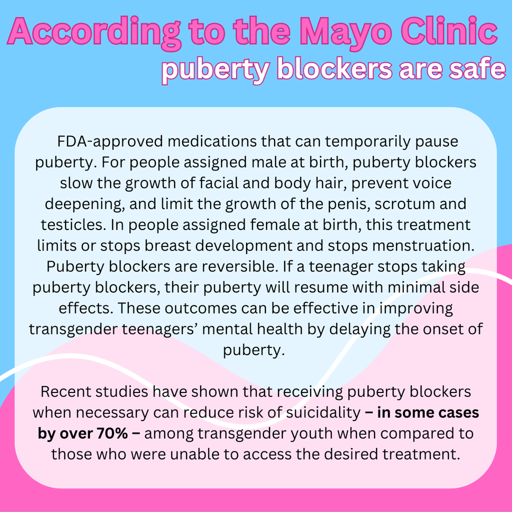

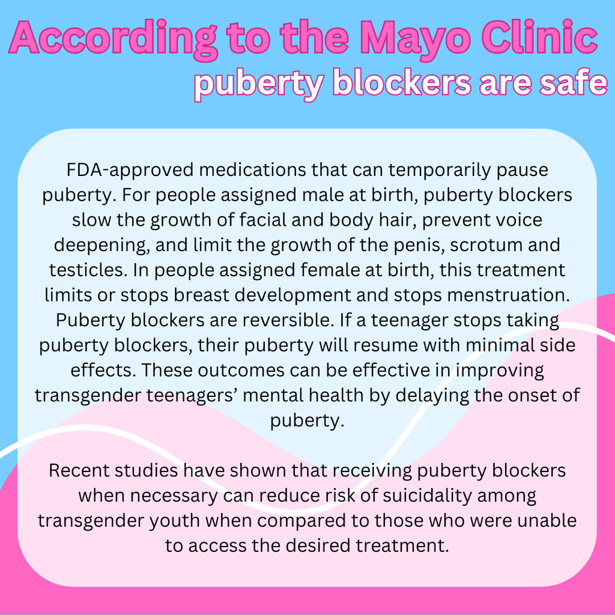

[figure not shown]

[figure not shown]

The experiment’s outcome variable is the degree of support for legislation banning gender-affirming care for minors. This was measured using a 5-point Likert type scale: Strongly Oppose (1), Slightly Oppose (2), Neutral (3), Slightly Approve (4), and Strongly Approve (5).

To complete the experiment, respondents first completed an informed consent form and were asked several demographic questions. Third variables of particular interest to our research are age, gender, region, and political affiliation. Next, survey respondents were asked a prior knowledge assessment question to determine prior bias and understanding of the topic: “True or False: Puberty blockers are a safe and reversible treatment when prescribed by medical professionals to treat gender dysphoria in transgender minors.” Finally, respondents were exposed to one of the four treatments, and they were then asked two questions to measure our outcome and check our manipulation. The outcome question was: “Would you support or oppose legislation to ban gender-affirming medical care such as puberty blockers for transgender minors under 18?” The manipulation check question was: “Do you support access to puberty blockers for transgender minors under 18 when deemed medically necessary?”

A total of 220 survey responses were collected.

# Data Cleaning

To clean our data, we renamed columns and decoded key demographic variables. Furthermore, we collapsed the categories for age, education, and political party to simplify the variables potentially included in our model. We also converted ordinal variables to numeric variables where appropriate.

```r
# import libraries
library(tidyverse)
library(ggplot2)
library(ggpubr)
library(ltm)

# read in data emailed to us by Professor Song
g1_data <- read.csv("fa24_g1.csv")

# start with 220 rows and 17 columns
dim(g1_data)
```

```
[1] 220  17
```

```r
# get rid of X column (repeat of id)
g1_data <- dplyr::select(g1_data, 2:17)

# rename some columns
g1_data <- g1_data |>
  rename(IV_stat = IV_info, gender_num = gender, hhi_num = hhi,
         ethnicity_num = ethnicity, hispanic_num = hispanic,
         education_num = education, political_party_num = political_party,
         region_num = region, gender_mfnb = g5sd1)

# change values of experiment questions and convert to factors
g1_data <- g1_data |>
  mutate(IV_org = as.factor(ifelse(IV_org == "no", "Non-credible", "Credible")),
         IV_stat = as.factor(ifelse(IV_stat == "no", "No statistic", "Statistic")),
         prior_knowledge = factor(g1q1, levels=c("True", "False")),
         DV_ban = factor(g1q2,
                          levels=c("Strongly oppose", "Slightly oppose", "Neutral",
                                   "Slightly support", "Strongly support"),
                          ordered=TRUE),
         manipulation_check = factor(g1q3,
                                     levels=c("Support", "Undecided",
                                              "Do not support"),
                                     ordered=TRUE))

# create gender_mf column
g1_data <- g1_data |>
  mutate(gender_mf = ifelse(gender_num==1, "Male", "Female"))

# create genders_equal column
g1_data <- g1_data |>
  mutate(genders_equal = ifelse(gender_mf == gender_mfnb, TRUE, FALSE))

# create hhi_txt column
g1_data <- g1_data |>
  mutate(hhi_txt = case_when(
    hhi_num == 1 ~ "Less than $14,999",
    hhi_num == 2 ~ "$15,000 to $19,999",
    hhi_num == 3 ~ "$20,000 to $24,999",
    hhi_num == 4 ~ "$25,000 to $29,999",
    hhi_num == 5 ~ "$30,000 to $34,999",
    hhi_num == 6 ~ "$35,000 to $39,999",
    hhi_num == 7 ~ "$40,000 to $44,999",
    hhi_num == 8 ~ "$45,000 to $49,999",
    hhi_num == 9 ~ "$50,000 to $54,999",
    hhi_num == 10 ~ "$55,000 to $59,999",
    hhi_num == 11 ~ "$60,000 to $64,999",
    hhi_num == 12 ~ "$65,000 to $69,999",
    hhi_num == 13 ~ "$70,000 to $74,999",
    hhi_num == 14 ~ "$75,000 to $79,999",
    hhi_num == 15 ~ "$80,000 to $84,999",
    hhi_num == 16 ~ "$85,000 to $89,999",
    hhi_num == 17 ~ "$90,000 to $94,999",
    hhi_num == 18 ~ "$95,000 to $99,999",
    hhi_num == 19 ~ "$100,000 to $124,999",
    hhi_num == 20 ~ "$125,000 to $149,999",
    hhi_num == 21 ~ "$150,000 to $174,999",
    hhi_num == 22 ~ "$175,000 to $199,999",
    hhi_num == 23 ~ "$200,000 to $249,999",
    hhi_num == 24 ~ "$250,000 and above"
  ) %>% as.factor())

# create ethnicity_txt and ethnicity_poc columns
g1_data <- g1_data |>
  mutate(ethnicity_txt = case_when(
    ethnicity_num == 1 ~ "White",
    ethnicity_num == 2 ~ "Black or African American",
    ethnicity_num == 3 ~ "American Indian or Alaska Native",
    ethnicity_num == 5 | ethnicity_num == 7 | ethnicity_num == 10 ~ "Asian",
    ethnicity_num == 15 ~ "Some other race",
    ethnicity_num == 16 ~ "Prefer not to answer",
  ) %>% as.factor())
g1_data <- g1_data |>
  mutate(ethnicity_poc = case_when(
    ethnicity_num == 1 ~ 0,
    ethnicity_num == 2 | ethnicity_num == 3 | ethnicity_num == 5 |
      ethnicity_num == 7 | ethnicity_num == 10 | ethnicity_num == 15 ~ 1,
    ethnicity_num == 16 ~ NA
  ))

# create hispanic_txt and hispanic_yes columns
g1_data <- g1_data |>
  mutate(hispanic_txt = case_when(
    hispanic_num == 1 ~ "No, not of Hispanic, Latino, or Spanish origin",
    hispanic_num == 2 ~ "Yes, Mexican, Mexican American, Chicano",
    hispanic_num == 3 ~ "Yes, Cuban",
    hispanic_num == 4 ~ "Yes, Argentinian",
    hispanic_num == 5 ~ "Yes, Colombian",
    hispanic_num == 9 ~ "Yes, Nicaraguan",
    hispanic_num == 10 ~ "Yes, Panamanian",
    hispanic_num == 12 ~ "Yes, Spanish",
    hispanic_num == 14 ~ "Yes, Other Country",
    hispanic_num == 16 ~ "Prefer not to answer",
  ))
g1_data <- g1_data |>
  mutate(hispanic_yes = case_when(
    hispanic_num == 1 ~ 0,
    hispanic_num == 2 | hispanic_num == 3 | hispanic_num == 4 |
      hispanic_num == 5 | hispanic_num == 9 | hispanic_num == 10 |
      hispanic_num == 12 | hispanic_num == 14 ~ 1,
    hispanic_num == 16 ~ NA
  ))

# create education_txt and education_cat columns
g1_data <- g1_data |>
  mutate(education_txt = case_when(
    education_num == 1 ~ "Some high school or less",
    education_num == 2 ~ "High school graduate",
    education_num == 3 ~ "Other post high school vocational training",
    education_num == 4 ~ "Completed some college, but no degree",
    education_num == 5 ~ "Associate's degree",
    education_num == 6 ~ "Bachelor's degree",
    education_num == 7 ~ "Master's or professional degree",
    education_num == 8 ~ "Doctorate degree",
    education_num == -3105 ~ "None of the above",
  ),
  education_cat = case_when(
    education_num < 4 ~ "High school",
    education_num < 6 ~ "Associate's/some college",
    education_num == 6 ~ "Bachelor's",
    education_num < 9 ~ "Advanced degree"
  ) %>% as.factor())

# create political_party_txt and political_party_dri columns
g1_data <- g1_data |>
  mutate(political_party_txt = case_when(
    political_party_num == 1 ~ "Strong Democrat",
    political_party_num == 2 ~ "Not very strong Democrat",
    political_party_num == 3 ~ "Independent Democrat",
    political_party_num == 4 ~ "Independent - neither",
    political_party_num == 5 ~ "Independent Republican",
    political_party_num == 6 ~ "Other - leaning Democrat",
    political_party_num == 7 ~ "Other - neither",
    political_party_num == 8 ~ "Other - leaning Republican",
  ) %>% as.factor())
g1_data <- g1_data |>
  mutate(political_party_dri = case_when(
    political_party_num == 1 | political_party_num == 2 |
      political_party_num == 3 | political_party_num == 6 ~ "Democrat",
    political_party_num == 5 | political_party_num == 8 ~ "Republican",
    political_party_num == 4 | political_party_num == 7 ~ "Independent"
  ) %>% as.factor)

# create region_txt column
g1_data <- g1_data |>
  mutate(region_txt = case_when(
    region_num == 1 ~ "Northeast",
    region_num == 2 ~ "Midwest",
    region_num == 3 ~ "South",
    region_num == 4 ~ "West",
  ) %>% as.factor())

# create age_cat column
g1_data <- g1_data %>%
  mutate(age_cat = case_when(
    age < 36 ~ "18-35",
    age < 50 ~ "36-49",
    age < 64 ~ "50-63",
    TRUE ~ "64+"
  ) %>% as.factor())

# modify zip column to replace leading 0s
g1_data <- g1_data |>
  mutate(zip = ifelse(zip < 10000, as.character(str_c('0',zip)), as.character(zip)))

# move columns so similar columns are near each other
g1_data <- g1_data |>
  relocate(gender_mf, .after=gender_num) |>
  relocate(gender_mfnb, .after=gender_mf) |>
  relocate(genders_equal, .after=gender_mfnb) |>
  relocate(hhi_txt, .after=hhi_num) |>
  relocate(ethnicity_txt, .after=ethnicity_num) |>
  relocate(ethnicity_poc, .after=ethnicity_txt) |>
  relocate(hispanic_txt, .after=hispanic_num) |>
  relocate(hispanic_yes, .after=hispanic_txt) |>
  relocate(education_txt, .after=education_num) |>
  relocate(political_party_txt, .after=political_party_num) |>
  relocate(political_party_dri, .after=political_party_txt) |>
  relocate(region_txt, .after=region_num) |>
  relocate(prior_knowledge, .after=g1q1) |>
  relocate(DV_ban, .after=g1q2) |>
  relocate(manipulation_check, .after=g1q3) |>
  relocate(age_cat, .after=age) |>
  relocate(education_cat, .after=education_txt)

# prepare data for analysis
clean_data <- g1_data %>%
  mutate(DV_ban_num = as.numeric(DV_ban),
         manipulation_check_num = as.numeric(manipulation_check),
         gender_mfnb = as.factor(gender_mfnb),
         DV_ban_3 = case_when(
           DV_ban_num < 3 ~ "Oppose",
           DV_ban_num == 3 ~ "Neutral",
           DV_ban_num > 3 ~ "Support"
         ) %>% factor(levels = c("Oppose", "Neutral", "Support"),
                      ordered=TRUE),
         DV_ban_3_num = as.numeric(DV_ban_3))

# create numeric column for pre-test
clean_data <- clean_data |>
  mutate(prior_knowledge_num = case_when(
    g1q1 == "True" ~ 1,
    g1q1 == "I don't know" ~ 2,
    g1q1 == "False" ~ 3))

# relocate more columns
clean_data <- clean_data |>
  relocate(DV_ban_num, .after=DV_ban) |>
  relocate(DV_ban_3, .after=DV_ban_num) |>
  relocate(DV_ban_3_num, .after=DV_ban_3) |>
  relocate(prior_knowledge_num, .after=prior_knowledge) |>
  relocate(manipulation_check_num, .after=manipulation_check)

# end with 220 rows and 37 columns
dim(clean_data)
```

```
[1] 220  37
```

# Analysis

To analyze the results of our survey, we will use a two-way factorial ANOVA model. Although the outcome variable is a Likert-type ordinal variable and not continuous, the Likert scale had five levels, which means it can approximate a continuous variable. Furthermore, our independent variable measures and demographic controls are all categorical variables, which provides groups for analysis rather than continuous predictors (like in traditional regression).

Upon exploring the distribution of our experiment variables, we observed high rates of neutral respondents, as well as “I don’t know” responses to our prior knowledge assessment.

```r
# explore experiment variables
summary(clean_data %>% dplyr::select(DV_ban, IV_stat, IV_org, manipulation_check, prior_knowledge))
```

```
              DV_ban           IV_stat             IV_org
 Strongly oppose :58   No statistic:112   Credible    :108
 Slightly oppose :25   Statistic   :108   Non-credible:112
 Neutral         :60
 Slightly support:34
 Strongly support:43
      manipulation_check prior_knowledge
 Support       :71       True : 55
 Undecided     :62       False: 63
 Do not support:87       NA's :102
```

```r
# explore demographic variables of interest
summary(clean_data %>% dplyr::select(gender_mfnb, education_cat, region_txt, political_party_dri, age_cat))
```

```
 gender_mfnb                   education_cat     region_txt
 Female:135   Advanced degree         :33    Midwest  : 46
 Male  : 85   Associate's/some college:54    Northeast: 53
              Bachelor's              :51    South    :100
              High school             :82    West     : 21
  political_party_dri  age_cat
 Democrat   :198      18-35:54
 Independent: 12      36-49:53
 Republican : 10      50-63:61
                      64+  :52
```

Prior to running the ANOVA model, we wanted to see if our manipulation check and outcome variable demonstrated consistent results. If the responses to our manipulation check and outcome variable aligned, we would expect to see that respondents who strongly oppose bans of gender-affirming care would support access to puberty blockers when medically necessary. We also expected to see a lack of support of access to puberty blockers among respondents who strongly support bans of gender-affirming care.

To test this, we collapsed the 5-level Likert scale outcome to a 3-level scale (Oppose, Neutral, Support) to fit the scale of the manipulation check. Then, we tested Cronbach’s alpha, which produces a value of -0.4. Thus, the manipulation check and outcome variable are not consistent. Of note, respondents who answered “do not support” to the manipulation check are very split on their support for legislation banning this care.

```r
# explore consistency with manipulation check, throw out any inconsistent results
table(clean_data$manipulation_check, clean_data$DV_ban)
```

```
                 Strongly oppose Slightly oppose Neutral Slightly support
  Support                     15               8      16               19
  Undecided                    7               5      35               11
  Do not support              36              12       9                4

                 Strongly support
  Support                      13
  Undecided                     4
  Do not support               26
```

```r
ltm::cronbach.alpha(clean_data %>% dplyr::select(manipulation_check, DV_ban_3), CI=T, standardized=T)
```

```
Standardized Cronbach's alpha for the 'clean_data %>% dplyr::select(manipulation_check, DV_ban_3)' data-set

Items: 2
Sample units: 220
alpha: -0.403

Bootstrap 95% CI based on 1000 samples
  2.5%  97.5%
-0.853 -0.054
```

# Results

First, we recreated our expected results plot using our real data. We observe very marginal differences in the breakdown of our outcome variable across treatment groups.

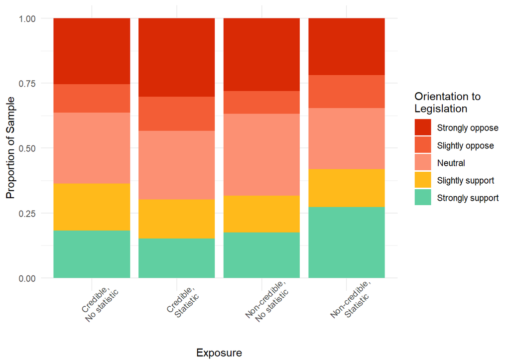

```r
library(paletteer)

# recreate expected results plot
summary_table <- g1_data %>%
  mutate(treatment = paste0(IV_org, ",\n", IV_stat)) %>%
  dplyr::select(treatment, DV_ban) %>%
  group_by(treatment, DV_ban) %>%
  summarize(value = n(), .groups="keep")
ggplot(summary_table, aes(fill=DV_ban, y=value, x=treatment)) +
    geom_bar(position="fill", stat="identity")  +
    labs(x = "Exposure", y = "Proportion of Sample",
         fill = "Orientation to\nLegislation") +
    scale_fill_paletteer_d("MoMAColors::Connors") +
    theme_minimal() +
    theme(axis.text.x = element_text(angle = 45))
```

**H1 & H2 results:** These hypotheses are related, and therefore we combined the results in a single plot. It’s telling that the distribution of our outcome variable looks practically identical for the credible, statistic group and the non-credible, no statistic group, when we were expecting these two groups to have the most drastic differences.

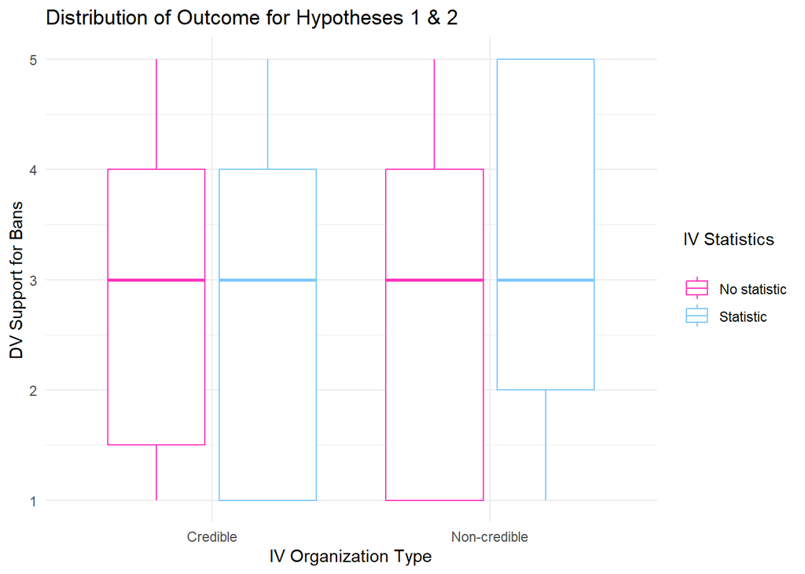

```r
#H1 & H2 Plot
ggboxplot(clean_data, x = "IV_org", y = "DV_ban_num", color = "IV_stat",
          palette = c("#ff33be", "#7cc8fc"))+
  labs(title = "Distribution of Outcome for Hypotheses 1 & 2",
       x = "IV Organization Type",
       y = "DV Support for Bans",
       color = "IV Statistics\n")+
  theme_minimal()
```

**H3 results:** Since our experiment had 2 independent variables, these results are reflected in 2 plots.

The first plot shows the relationship between respondents’ prior knowledge and support for access to puberty blockers for transgender minors when medically necessary, grouped by whether they received credible information or not. This plot aligns more with our expectations, because respondents who answered true to our prior knowledge question (indicating that they know puberty blockers are safe and reversible medications for transgender minors) were more likely to support access to puberty blockers (represented by lower values of the manipulation check variable). Similarly, respondents who answered false to our prior knowledge question were more likely to oppose access to puberty blockers (represented by higher values of the manipulation check variable). The credibility of the source didn’t seem to have much impact on these results.

The second plot shows the relationship between respondents’ prior knowledge and support for puberty blockers, grouped by whether they received a statistic about the effectiveness of puberty blockers or not. Like the prior plot, this plot shows that people with prior belief in puberty blockers are more likely to support access to them, while people with prior disbelief in puberty blockers are more likely to oppose access to them, regardless of whether they were shown the statistic or not.

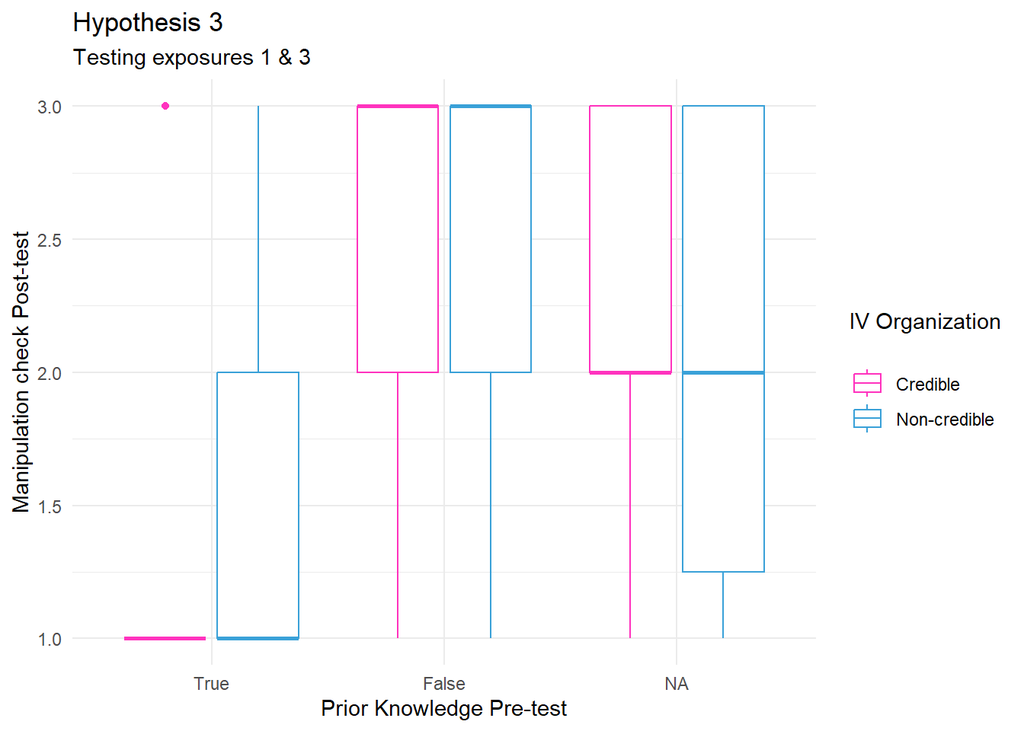

```r
#H3 Plot
ggboxplot(clean_data, x = "prior_knowledge", y = "manipulation_check_num",
          color = c("IV_org"),
          palette = c("#ff33be", "#3aa1d8"))+
  labs(title = "Hypothesis 3",
       subtitle = "Testing exposures 1 & 3",
       x = "Prior Knowledge Pre-test",
       y = "Manipulation check Post-test",
       color = "IV Organization\n")+
  theme_minimal()
```

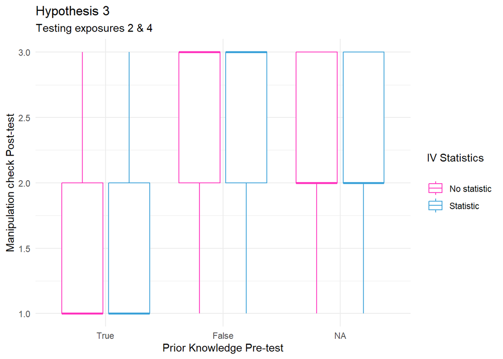

```r
ggboxplot(clean_data, x = "prior_knowledge", y = "manipulation_check_num",
          color = c("IV_stat"),
          palette = c("#ff33be", "#3aa1d8"))+
  labs(title = "Hypothesis 3",
       subtitle = "Testing exposures 2 & 4",
       x = "Prior Knowledge Pre-test",
       y = "Manipulation check Post-test",
       color = "IV Statistics\n")+
  theme_minimal()
```

# Findings

We proceeded to run the ANOVA analysis and view the results of the interaction plot for our two independent variables. We report neither of our independent variables nor their interaction term as statistically significant predictors of our outcome variable. The only third variable with a statistically significant relationship to the outcome variable is gender. Thus, in this case we cannot reject the null hypothesis that information credibility, informed by inclusion of either a source and/or a statistic, does not affect support for legislation.

This is confirmed in the interaction plot which shows, very small, non-parallel slopes of the two lines. We had expected the credible, statistic group to have lower values of our outcome variable (since 1 and 2 represent opposition to legislation banning gender-affirming care) and the non-credible, no statistic group to have higher values of our outcome variable (since 4 and 5 represent support for legislation banning gender-affirming care). In reality, each of the four groups’ views toward legislation banning gender-affirming care hover around 3 on the y-axis, indicating neutral or mixed feelings.

```r
# confirm numeric structure of the data
str(clean_data %>% dplyr::select(DV_ban_num, IV_org, IV_stat, gender_mfnb,
                                 region_txt, age_cat, education_cat,
                                 manipulation_check, prior_knowledge))
```

```
'data.frame':   220 obs. of  9 variables:
 $ DV_ban_num        : num  1 2 3 3 1 5 3 2 1 1 ...
 $ IV_org            : Factor w/ 2 levels "Credible","Non-credible": 1 2 1 2 2 1 1 1 1 2 ...
 $ IV_stat           : Factor w/ 2 levels "No statistic",..: 1 2 2 1 1 1 2 2 1 1 ...
 $ gender_mfnb       : Factor w/ 2 levels "Female","Male": 1 1 2 1 1 2 1 1 1 2 ...
 $ region_txt        : Factor w/ 4 levels "Midwest","Northeast",..: 3 3 4 4 1 3 1 3 2 3 ...
 $ age_cat           : Factor w/ 4 levels "18-35","36-49",..: 2 4 1 2 3 1 2 1 2 4 ...
 $ education_cat     : Factor w/ 4 levels "Advanced degree",..: 4 4 2 4 3 3 2 4 1 1 ...
 $ manipulation_check: Ord.factor w/ 3 levels "Support"<"Undecided"<..: 3 3 1 2 3 1 1 3 3 3 ...
 $ prior_knowledge   : Factor w/ 2 levels "True","False": 1 1 1 NA 2 2 1 1 NA 2 ...
```

```r
# two-way ANOVA with interaction using 5-category outcome (numeric)
aov_results <- aov(DV_ban_num ~ IV_org * IV_stat + gender_mfnb + region_txt +
                     age_cat + education_cat, data = clean_data)
summary(aov_results)
```

```
                Df Sum Sq Mean Sq F value Pr(>F)
IV_org           1    1.4   1.374   0.654 0.4196
IV_stat          1    0.1   0.097   0.046 0.8303
gender_mfnb      1   11.1  11.103   5.287 0.0225 *
region_txt       3    1.2   0.387   0.184 0.9069
age_cat          3    7.1   2.367   1.127 0.3392
education_cat    3    4.3   1.446   0.689 0.5600
IV_org:IV_stat   1    3.2   3.189   1.519 0.2192
Residuals      206  432.6   2.100
---
Signif. codes:  0 '***' 0.001 '**' 0.01 '*' 0.05 '.' 0.1 ' ' 1
```

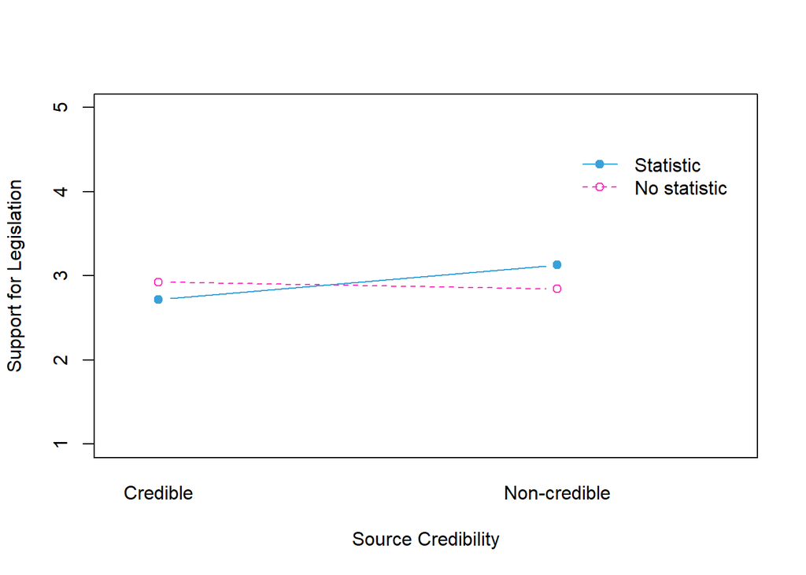

```r
# interaction plot
interaction.plot(x.factor = clean_data$IV_org, trace.factor = clean_data$IV_stat,
                 response = clean_data$DV_ban_num, fun = mean,
                 type = "b", legend = TRUE,
                 xlab = "Source Credibility", ylab = "Support for Legislation",
                 pch = c(1, 19), col = c("#ff33be", "#3aa1d8"), ylim =c(1,5),
                 labs(color=""))
```

We ran a similar model to test our third hypothesis, using prior knowledge as our main predictor. However, since the F-statistic for prior knowledge is small (0.577) with a p-value of 0.4493, there is no statistical evidence to reject the null hypothesis that prior knowledge that puberty blockers are safe has a relationship with support for legislation to ban.

```r
# Two-way ANOVA with interaction using 5-category outcome (numeric)
aov_results <- aov(DV_ban_num ~ prior_knowledge + gender_mfnb + region_txt +
                     age_cat + education_cat, data = clean_data)
summary(aov_results)
```

```
                 Df Sum Sq Mean Sq F value Pr(>F)
prior_knowledge   1   1.34   1.339   0.577 0.4493
gender_mfnb       1   7.12   7.122   3.066 0.0828 .
region_txt        3   0.94   0.313   0.135 0.9391
age_cat           3  13.68   4.559   1.963 0.1240
education_cat     3  14.16   4.719   2.032 0.1139
Residuals       106 246.22   2.323
---
Signif. codes:  0 '***' 0.001 '**' 0.01 '*' 0.05 '.' 0.1 ' ' 1
102 observations deleted due to missingness
```

```r
# manipulation check as outcome
aov_results <- aov(manipulation_check_num ~ prior_knowledge + gender_mfnb +
                     age_cat + education_cat + region_txt, data = clean_data)
summary(aov_results)
```

```
                 Df Sum Sq Mean Sq F value   Pr(>F)
prior_knowledge   1  22.90  22.901  34.130 5.73e-08 ***
gender_mfnb       1   0.59   0.588   0.877    0.351
age_cat           3   1.48   0.493   0.734    0.534
education_cat     3   1.13   0.376   0.560    0.643
region_txt        3   0.75   0.248   0.370    0.775
Residuals       106  71.13   0.671
---
Signif. codes:  0 '***' 0.001 '**' 0.01 '*' 0.05 '.' 0.1 ' ' 1
102 observations deleted due to missingness
```